# 03. (otimizado) modelos

Author

Matheus Lazzari Nicola

# base de dados

**mostre-me o código**

```r
path.01 = "C:/Users/mathe/OneDrive/4.0 Pós-graduação/4.4b Dissertação Mestrado Profissional/c. exploração de dados/atrasos_processo.RData"
load(path.01)

#write.csv(inicio.processo, "inicio_processo.csv", row.names = FALSE)

# Definir as variáveis endógenas (Y)
endogenas <- c(
  'tranp_atrasou_carreg',
  'cliente_atrasou_carreg',
  'atrasou',
  'diferenca_agenda_chegada',
  'diferenca_agenda_carreg',
  'delta_carregamento',
  'delta_fim_inicio',
  'motorista',
  'cenarios'
)

# Definir as variáveis a serem descartadas
descartadas = c('interestado', 'numero_paradas.gris', 'cliente_monitora',
                'ERAS_DESCRICAO', 'delta_inicio_cadastro', 'delta_pinicio_inicio',
                'delta_pfim_fim', 'intraestado')

# Criar a lista de variáveis exógenas (X) excluindo as variáveis endógenas e as descartadas
exogenas = setdiff(names(inicio.processo), c(endogenas, descartadas))

inicio.processo = inicio.processo |>
                  droplevels() |>
                  mutate(PALLETS = as.numeric(substr(PALLETS, 1, 2)))

# Criar os data frames Y e X
Y = inicio.processo[, endogenas]
X = inicio.processo[, exogenas]


# FAMD é adequada para conjuntos de dados mistos (numéricos e categóricos)
dados_logit = inicio.processo[, c('atrasou', names(X))] |> droplevels()
attr(dados_logit, "na.action") <- NULL
dados_logit <- unique(dados_logit)

dados_mnomial = inicio.processo[, c('cenarios', names(X))] |> droplevels()
attr(dados_mnomial, "na.action") <- NULL
dados_mnomial <- unique(dados_mnomial)

rm(path.01, endogenas, descartadas, exogenas)
```

# Análise de Fatores de Dados Mistos (FAMD)

FAMD é um método de componentes principais dedicado a explorar dados com variáveis tanto contínuas quanto categóricas. Pode ser visto, de forma simplificada, como uma mistura entre PCA (Análise de Componentes Principais) e MCA (Análise de Correspondência Múltipla). Mais precisamente, as variáveis contínuas são escaladas para variância unitária, e as variáveis categóricas são transformadas em uma tabela de dados disjuntivos (codificação crisp) e, em seguida, escaladas usando a escala específica do MCA. Isso garante o equilíbrio da influência de ambas as variáveis contínuas e categóricas na análise. Isso significa que ambos os tipos de variáveis estão em igualdade de condições para determinar as dimensões de variabilidade. Este método permite estudar as similaridades entre indivíduos, levando em conta variáveis mistas, e analisar as relações entre todas as variáveis. Também fornece resultados gráficos, como a representação dos indivíduos, o círculo de correlação para as variáveis contínuas e representações das categorias das variáveis categóricas, além de gráficos específicos para visualizar as associações entre ambos os tipos de variáveis.

HUSSON, François; JOSSE, Julie; LE, Sébastien; MAZET, Jeremy. FactoMineR: Multivariate Exploratory Data Analysis and Data Mining. Versão 2.11. R Package. Disponível em: http://factominer.free.fr. Acesso em: 4 out. 2024.

Na função FAMD (Factor Analysis for Mixed Data) do pacote FactoMineR, a variável *sup.var* é um vetor que indica os índices das variáveis suplementares. Essas variáveis suplementares não participam diretamente na construção dos eixos principais, mas são projetadas posteriormente no espaço fatoral criado pelas variáveis ativas.

**Variância Explicada**

OS gráficos abaixo ajudam a entender a quantidade de variância explicada por cada tipo de variável e permitem decidir quantos componentes usar em análises posteriores, dependendo do nível de explicação de variância desejado.

**mostre-me o código**

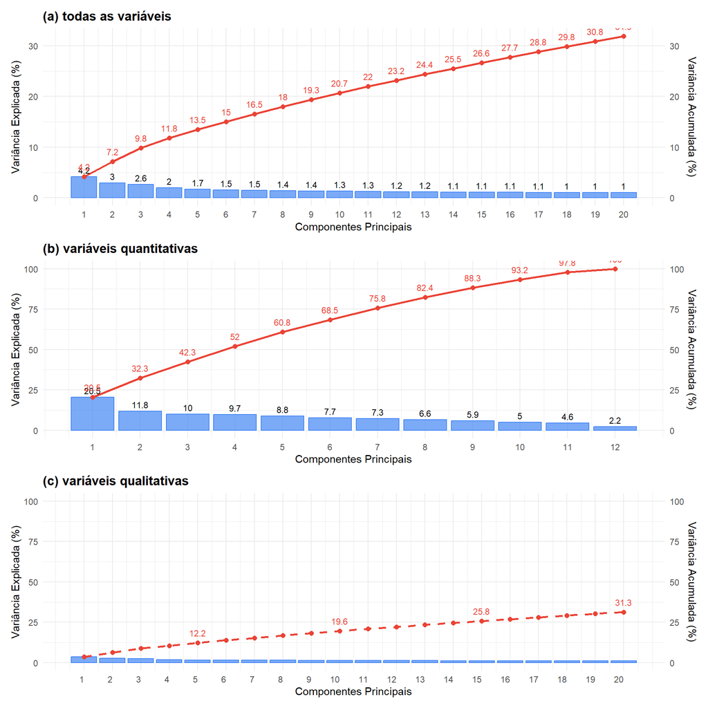

```r
# Identificar variáveis quantitativas (numéricas) e qualitativas (fatores)
quanti_vars = sapply(dados_logit, is.numeric)
quali_vars  = !quanti_vars

# Excluir a variável suplementar (por exemplo, a primeira coluna) das listas
sup_var = 1  # Índice da variável suplementar
quanti_vars[sup_var] = FALSE
quali_vars[sup_var] = FALSE

# Criar data frames separados, incluindo a variável suplementar
dados_all = dados_logit[,-1]  # Todas as variáveis
dados_quanti = dados_logit[, c(which(quanti_vars))]
dados_quali = dados_logit[, c(which(quali_vars))]

# Executar FAMD em todas as variáveis
famd_result = FAMD(dados_all, ncp = 20, graph = FALSE)
# Executar PCA nas variáveis quantitativas
pca_result = PCA(dados_quanti, ncp = 20, graph = FALSE)
# Executar MCA nas variáveis qualitativas
mca_result = MCA(dados_quali, ncp = 20, graph = FALSE)




# Definir a função para criar o gráfico de variância explicada
plot_variance_explained <- function(modelo, title_text) {
  # Calcular a variância explicada e a variância acumulada
  explained_variance <- modelo$eig[, 2]
  cumulative_variance <- cumsum(explained_variance)

  # Criar o data frame para o plot
  df_variance <- data.frame(
    Component = 1:length(explained_variance),
    Explained = explained_variance,
    Cumulative = cumulative_variance
  )

  # Criar o gráfico
  p <- ggplot(data = df_variance, aes(x = Component)) +
    geom_bar(aes(y = Explained), stat = "identity", fill = "#4285F4", alpha = 0.7, color = "#4285F4") + # Barras azuis
    geom_line(aes(y = Cumulative), color = "#EA4335", linewidth = 1) + # Linha vermelha
    geom_point(aes(y = Cumulative), color = "#EA4335", size = 2) + # Pontos vermelhos
    geom_text(aes(y = Explained, label = round(Explained, 1)), vjust = -0.5, size = 3) + # Rótulos das barras
    geom_text(aes(y = Cumulative, label = round(Cumulative, 1)), vjust = -1, size = 3, color = "#EA4335") + # Rótulos da linha acumulada
    scale_y_continuous(sec.axis = sec_axis(~., name = "Variância Acumulada (%)")) +
    scale_x_continuous(breaks = 1:length(explained_variance)) +
    labs(
      title = title_text,
      x = "Componentes Principais",
      y = "Variância Explicada (%)"
    ) +
    theme_minimal() +
    theme(
      legend.position = "none",
      text = element_text(family = "sans"),
      plot.title = element_text(face = "bold", hjust = 0)
    )

  return(p)
}


plot_mca_variance_explained <- function(mca_result, title_text) {
  # Extrair a variância explicada e a variância acumulada do resultado da MCA
  explained_variance <- mca_result$eig[, 2]
  cumulative_variance <- cumsum(explained_variance)

  # Limitar a visualização aos 20 primeiros componentes
  max_components <- 20
  explained_variance <- explained_variance[1:max_components]
  cumulative_variance <- cumulative_variance[1:max_components]

  # Criar o data frame para o plot
  df_variance <- data.frame(
    Component = 1:max_components,
    Explained = explained_variance,
    Cumulative = cumulative_variance
  )

  # Criar o gráfico
  p <- ggplot(data = df_variance, aes(x = Component)) +
    geom_bar(aes(y = Explained), stat = "identity", fill = "#4285F4", alpha = 0.7, color = "#4285F4") + # Barras azuis
    geom_line(aes(y = Cumulative), color = "#EA4335", linewidth = 1, linetype = "dashed") + # Linha vermelha pontilhada
    geom_point(aes(y = Cumulative), color = "#EA4335", size = 2) + # Pontos vermelhos
    geom_text(aes(y = Explained, label = ifelse(Explained > 5, round(Explained, 1), "")), vjust = -0.5, size = 3) + # Rótulos das barras
    geom_text(aes(y = Cumulative, label = ifelse(Component %% 5 == 0, round(Cumulative, 1), "")), vjust = -1, size = 3, color = "#EA4335") + # Rótulos da linha acumulada
    scale_y_continuous(limits = c(0, 100), sec.axis = sec_axis(~., name = "Variância Acumulada (%)")) +
    scale_x_continuous(breaks = 1:max_components) +
    labs(
      title = title_text,
      x = "Componentes Principais",
      y = "Variância Explicada (%)"
    ) +
    theme_minimal() +
    theme(
      legend.position = "none",
      text = element_text(family = "sans"),
      plot.title = element_text(face = "bold", hjust = 0),
      axis.text.x = element_text(angle = 0, hjust = 1)
    )

  return(p)
}


# Gerar os gráficos para cada análise
p_famd = plot_variance_explained(famd_result, "(a) todas as variáveis")
p_quanti = plot_variance_explained(pca_result, "(b) variáveis quantitativas")
p_quali = plot_mca_variance_explained(mca_result, "(c) variáveis qualitativas")

# Dispor os gráficos lado a lado usando o patchwork
combined_plot = p_famd + p_quanti + p_quali + plot_layout(ncol = 1)

# Exibir o gráfico combinado
print(combined_plot)
```

Gráfico (a): Todas as Variáveis

Gráfico (b): Variáveis Quantitativas

- Este gráfico representa os componentes principais resultantes de uma PCA (Análise de Componentes Principais) apenas para as variáveis quantitativas.
- Aqui, a variância explicada pelo primeiro componente é significativamente maior, com 20,5%, e a variância acumulada cresce rapidamente, em relação ao gráfico (a).
- Com apenas cinco componentes, mais de 50% da variância total das variáveis quantitativas é explicada, e com 12 componentes, alcança-se aproximadamente 100% de variância explicada.
- Isso indica que as variáveis quantitativas possuem uma estrutura mais compacta e que menos componentes são necessários para descrever adequadamente a variância.

Gráfico (c): Variáveis Qualitativas

**Contribuição das Variáveis**

**mostre-me o código**

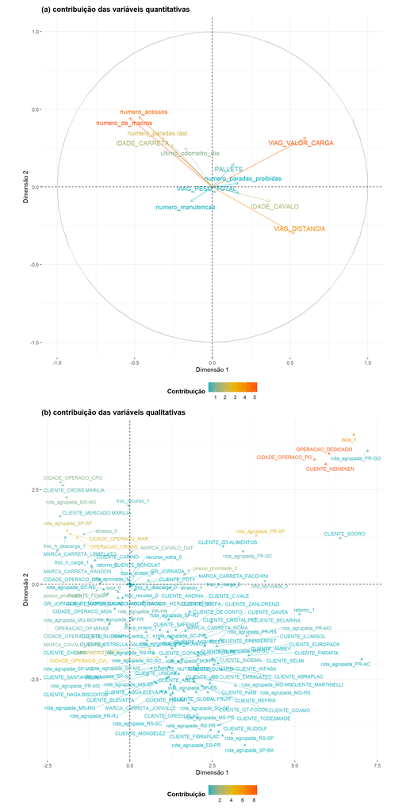

```r
p_quanti_contr <- fviz_famd_var(famd_result,
                          choice = "quanti.var",
                          repel = TRUE,
                          col.var = "contrib",
                          alpha.var = 0.7,
                          gradient.cols = c("#00AFBB", "#E7B800", "#FC4E07"),
                          ggtheme = theme_minimal()) +
            labs(
              title = "(a) contribuição das variáveis quantitativas",
              x = "Dimensão 1",
              y = "Dimensão 2",
              color = "Contribuição"
            ) +
            theme(
              plot.title = element_text(hjust = 0, face = "bold"),
              legend.position = "bottom",
              legend.title = element_text(face = "bold")
            )


dados_logit_factor = dados_logit |>
                     mutate(across(where(is.factor), ~ {
                       factor(paste(cur_column(), as.character(.), sep = "_"))}))

famd_result_factor = FAMD(dados_logit_factor, graph = FALSE)

p_quali_contr <- fviz_famd_var(famd_result_factor,
                          choice = "quali.var",
                          repel = TRUE,
                          col.var = "contrib",
                          alpha.var = 0.7,
                          gradient.cols = c("#00AFBB", "#E7B800", "#FC4E07"),
                          labelsize = 3,
                          ggtheme = theme_minimal()) +
            labs(
              title = "(b) contribuição das variáveis qualitativas",
              x = "Dimensão 1",
              y = "Dimensão 2",
              color = "Contribuição"
            ) +
            theme(
              plot.title = element_text(hjust = 0, face = "bold"),
              legend.position = "bottom",
              legend.title = element_text(face = "bold"),
            )

combined_plot_qq = p_quanti_contr + p_quali_contr + plot_layout(ncol = 1)

print(combined_plot_qq)
```

Gráfico (a): Contribuição das Variáveis Quantitativas

- Este gráfico mostra a contribuição das variáveis quantitativas para as duas primeiras dimensões (Dimensão 1 e Dimensão 2).
- Cada vetor representa uma variável quantitativa, com a direção e o comprimento do vetor indicando a contribuição e a importância da variável para as dimensões principais.
- As variáveis mais próximas da borda do círculo, como numero_acessos, numero_de_macros, VIAG_VALOR_CARGA, e VIAG_DISTANCIA, contribuem mais para a variabilidade explicada nas primeiras duas dimensões.
- A coloração dos vetores indica o nível de contribuição de cada variável (com tons mais próximos do vermelho significando maior contribuição). Isso é útil para identificar quais variáveis são mais influentes nas dimensões principais.

Por exemplo, as variáveis VIAG_VALOR_CARGA e VIAG_DISTANCIA têm uma alta contribuição para a Dimensão 1, sugerindo que variáveis relacionadas ao valor e distância das viagens são relevantes para descrever a variabilidade no conjunto de dados.

Gráfico (b): Contribuição das Variáveis Qualitativas

- Este gráfico mostra a contribuição das variáveis qualitativas para as mesmas duas dimensões.
- Cada ponto representa uma categoria de uma variável qualitativa (por exemplo, OPERACAO_DEDICADO, CLIENTE_HEINEKEN, rota_agrupada_PR-GO), e a coloração representa o nível de contribuição da categoria.
- Categorias que estão mais distantes da origem e mais próximas das bordas, como OPERACAO_DEDICADO, CLIENTE_HEINEKEN e rota_agrupada_PR-GO, têm uma contribuição maior para as dimensões. A escala de cores novamente indica a contribuição, com tons mais quentes (próximos ao laranja/vermelho) representando contribuições mais altas.

As categorias como OPERACAO_DEDICADO e CLIENTE_HEINEKEN contribuem significativamente para as dimensões principais, o que pode indicar que certos clientes e operações específicas influenciam a variabilidade do conjunto de dados.

**Variáveis Relevantes**

Os gráficos abaixo mostram a contribuição de cada variável que maximizam a explicação da variância pelos cinco primeiros componentes pricipais de cada técnica utilizada (FMDA, PCA e MCA).

**mostre-me o código**

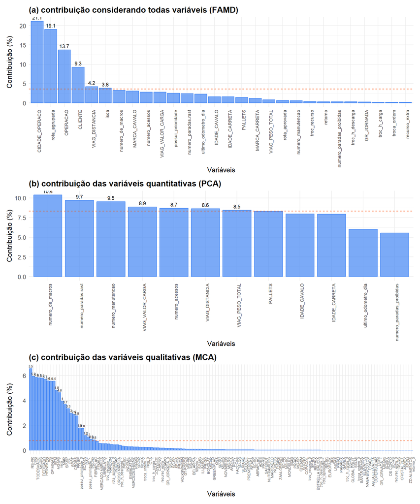

```r
# Definir ajustes de tema comuns
common_theme <- theme_minimal() +
  theme(
    legend.position = "none",
    text = element_text(family = "sans", size = 12),
    plot.title = element_text(face = "bold", hjust = 0, size = 14),
    axis.title = element_text(size = 12),
    axis.text.x = element_text(angle = 90, hjust = 1, size = 8),
    axis.text.y = element_text(size = 10)
  )

# ---- c_famd ----
# Extrair dados do gráfico c_famd
data_famd <- fviz_contrib(
  famd_result,
  choice = "var",
  axes = 1:5,
  top = 20
)$data

# Reordenar níveis de 'name'
data_famd$name <- factor(data_famd$name, levels = data_famd$name[order(data_famd$contrib, decreasing = TRUE)])

# Calcular contribuição média esperada
n_variables <- nrow(data_famd)
mean_contrib <- 100 / n_variables

# Criar o gráfico c_famd
c_famd <- ggplot(data_famd, aes(x = name, y = contrib)) +
  geom_bar(stat = "identity", fill = "#4285F4", color = "#4285F4", alpha = 0.7) +
  geom_hline(yintercept = mean_contrib, linetype = "dashed", color = "#FC4E07") +
  geom_text(aes(label = ifelse(contrib > mean_contrib, round(contrib, 1), "")),
            vjust = -0.5, size = 3) +
  labs(
    title = "(a) contribuição considerando todas variáveis (FAMD)",
    x = "Variáveis",
    y = "Contribuição (%)"
  ) +
  common_theme

# ---- c_pca ----
# Extrair dados do gráfico c_pca
data_pca <- fviz_contrib(
  pca_result,
  choice = "var",
  axes = 1:5,
  top = 20
)$data

# Reordenar níveis de 'name'
data_pca$name <- factor(data_pca$name, levels = data_pca$name[order(data_pca$contrib, decreasing = TRUE)])

# Calcular contribuição média esperada
n_variables_pca <- nrow(data_pca)
mean_contrib_pca <- 100 / n_variables_pca

# Criar o gráfico c_pca
c_pca <- ggplot(data_pca, aes(x = name, y = contrib)) +
  geom_bar(stat = "identity", fill = "#4285F4", color = "#4285F4", alpha = 0.7) +
  geom_hline(yintercept = mean_contrib_pca, linetype = "dashed", color = "#FC4E07") +
  geom_text(aes(label = ifelse(contrib > mean_contrib_pca, round(contrib, 1), "")),
            vjust = -0.5, size = 3) +
  labs(
    title = "(b) contribuição das variáveis quantitativas (PCA)",
    x = "Variáveis",
    y = "Contribuição (%)"
  ) +
  common_theme

# ---- c_mca ----
# Extrair dados do gráfico c_mca
data_mca <- fviz_contrib(
  mca_result,
  choice = "var",
  axes = 1:5,
  top = 20
)$data

# Reordenar níveis de 'name'
data_mca$name <- factor(data_mca$name, levels = data_mca$name[order(data_mca$contrib, decreasing = TRUE)])

# Calcular contribuição média esperada
n_variables_mca <- nrow(data_mca)
mean_contrib_mca <- 100 / n_variables_mca

# Criar o gráfico c_mca
c_mca <- ggplot(data_mca, aes(x = name, y = contrib)) +
  geom_bar(stat = "identity", fill = "#4285F4", color = "#4285F4", alpha = 0.7) +
  geom_hline(yintercept = mean_contrib_mca, linetype = "dashed", color = "#FC4E07") +
  geom_text(aes(label = ifelse(contrib > mean_contrib_mca, round(contrib, 1), "")),
            vjust = -0.5, size = 2) +
  labs(
    title = "(c) contribuição das variáveis qualitativas (MCA)",
    x = "Variáveis",
    y = "Contribuição (%)"
  ) +
  theme_minimal() +
  theme(
    legend.position = "none",
    text = element_text(family = "sans", size = 12),
    plot.title = element_text(face = "bold", hjust = 0, size = 14),
    axis.title = element_text(size = 12),
    axis.text.x = element_text(angle = 90, hjust = 1, size = 6),
    axis.text.y = element_text(size = 10)
  )

combined_plot_c = c_famd + c_pca + c_mca + plot_layout(ncol = 1)

# Exibir o gráfico combinado
print(combined_plot_c)
```

No gráfico acima, são apresentadas as contribuições de cada técnica de Análise de Componentes Principais (FAMD, PCA e MCA). As barras indicam a contribuição percentual de cada variável para as principais dimensões (neste caso, as cinco primeiras), que capturam a variação nos dados de diferentes tipos: dados mistos para a FAMD, dados quantitativos para a PCA e dados qualitativos para a MCA.

# Redução de Dimensionalidade

O objetivo do pacote glmnet é fornecer ferramentas para ajuste de modelos lineares generalizados com regularização, particularmente utilizando as penalizações Lasso, Ridge e Elastic Net. Ele é projetado para modelagem estatística onde a seleção de variáveis e a regularização são essenciais, principalmente em conjuntos de dados de alta dimensionalidade. O pacote facilita a construção de modelos preditivos robustos que evitam o overfitting ao penalizar coeficientes de variáveis menos relevantes, permitindo que o modelo se concentre nas características mais importantes.

FRIEDMAN, Jerome; HASTIE, Trevor; TIBSHIRANI, Rob; NARASIMHAN, Balasubramanian; TAY, Kenneth; SIMON, Noah. glmnet: Lasso and Elastic-Net Regularized Generalized Linear Models. R package version, 2023. Disponível em: https://cran.r-project.org/package=glmnet. Acesso em: 19 out. 2024.

**sp**

**Lasso**: Ideal para reduzir a dimensionalidade, selecionando apenas as variáveis mais relevantes. Útil em situações de esparsidade, onde se espera que apenas algumas variáveis tenham impacto significativo.

**Ridge**: Recomendado para cenários com muitas variáveis correlacionadas, onde todas são consideradas relevantes. Mantém todas as variáveis no modelo, mas reduz seus efeitos para evitar overfitting.

**Elastic Net**: Útil para dados com muitas variáveis correlacionadas e onde uma combinação de seleção e regularização é desejável. É um bom “meio-termo” entre Lasso e Ridge, adaptando-se bem a uma variedade de cenários.

**mostre-me o código**

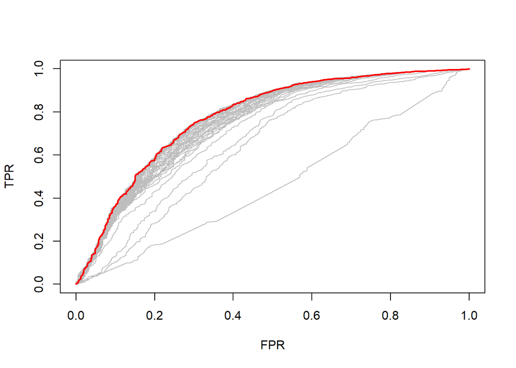

```r
# Preparar dados
X = model.matrix(atrasou ~ . -1, data = dados_logit)  # Matriz de preditores
y = dados_logit$atrasou                               # Variável resposta

# Validação cruzada para escolher o melhor lambda
modelo_elastic = cv.glmnet(X, y, family = "binomial",
                           alpha = 0.5,
                           maxit = 100000,
                           standardize = TRUE,
                           type.measure = "auc",
                           keep = TRUE)

rocs <-roc.glmnet(modelo_elastic$fit.preval,newy = y)

best = modelo_elastic$index["min",]
plot(rocs[[best]], type ="l")
invisible(sapply(rocs,lines,col="grey"))
lines(rocs[[best]],lwd =2,col ="red")
```

**teste**

**mostre-me o código**

```r
# Extrair o melhor lambda
#best_lambda = modelo_elastic$lambda.min

# Ajustar modelo final com o lambda ótimo
#modelo_logit = glmnet(X, y, alpha = 0.5,
#                      family = "binomial",
#                      lambda = seq(best_lambda * 2, best_lambda * 0.5, length = 100),
#                      maxit = 100000,
#                      standardize = TRUE,
#                      thresh = 1e-3,
#                      type.logistic = "modified.Newton",
#                      strong = TRUE)

#coeficientes <- coef(modelo_logit)
#print(coeficientes)
```

# Modelos

**treino e teste**

**mostre-me o código**

```r
# Base binária
dados_logit$atrasou <- as.factor(dados_logit$atrasou)
levels(dados_logit$atrasou)
```

```
[1] "0" "1"
```

**mostre-me o código**

```r
# Base multinomial
dados_mnomial$cenarios <- as.factor(dados_mnomial$cenarios)
levels(dados_mnomial$cenarios)
```

```
[1] "1" "2" "3" "4"
```

**mostre-me o código**

```r
# Verificar valores ausentes na base binária
sum(is.na(dados_logit))
```

```
[1] 0
```

**mostre-me o código**

```r
# Verificar valores ausentes na base multinomial
sum(is.na(dados_mnomial))
```

```
[1] 0
```

**mostre-me o código**

```r
# Verificar o balanceamento da variável resposta binária
table(dados_logit$atrasou)
```

```
   0    1
 553 5091
```

**mostre-me o código**

```r
# Se necessário, balancear os dados de treino binário
if (min(table(dados_logit$atrasou)) / sum(table(dados_logit$atrasou)) < 0.1) {
  cat("A variável resposta está desbalanceada. Realizando balanceamento...\n")
  treinoBin_bal <- upSample(x = dados_logit[, -which(names(dados_logit) == 'atrasou')], y = dados_logit$atrasou)
  treinoBin <- cbind(treinoBin_bal, atrasou = treinoBin_bal$Class)
  treinoBin$Class <- NULL
} else {
  treinoBin <- dados_logit
}
```

```
A variável resposta está desbalanceada. Realizando balanceamento...
```

**mostre-me o código**

```r
# Definir as variáveis preditoras

# Variáveis preditoras para a base binária (excluindo a variável resposta e identificadores não adequados)
predictors_logit <- setdiff(names(dados_logit), c('atrasou', 'CLIENTE', 'rota_agrupada'))

# Remover variáveis constantes (sem variação)
predictors_logit <- predictors_logit[sapply(treinoBin[, predictors_logit], function(x) length(unique(x)) > 1)]

# Variáveis preditoras para a base multinomial (excluindo a variável resposta e identificadores não adequados)
predictors_mnomial <- setdiff(names(dados_mnomial), c('cenarios', 'CLIENTE', 'rota_agrupada'))

# Passo 3: Dividir os dados em conjuntos de treinamento e teste
set.seed(123)  # Para reprodutibilidade

# Divisão para a base binária
indiceTreinoBin <- createDataPartition(dados_logit$atrasou, p = 0.7, list = FALSE)
treinoBin <- dados_logit[indiceTreinoBin, ]
testeBin <- dados_logit[-indiceTreinoBin, ]

# Ajustar níveis dos fatores no conjunto de teste para que sejam consistentes com o conjunto de treinamento
for (var in names(treinoBin)) {
  if (is.factor(treinoBin[[var]])) {
    levels(testeBin[[var]]) <- levels(treinoBin[[var]])
  }
}

# Divisão para a base multinomial
indiceTreinoMulti <- createDataPartition(dados_mnomial$cenarios, p = 0.7, list = FALSE)
treinoMulti <- dados_mnomial[indiceTreinoMulti, ]
testeMulti <- dados_mnomial[-indiceTreinoMulti, ]

# Ajustar níveis dos fatores no conjunto de teste para que sejam consistentes com o conjunto de treinamento
for (var in names(treinoMulti)) {
  if (is.factor(treinoMulti[[var]])) {
    levels(testeMulti[[var]]) <- levels(treinoMulti[[var]])
  }
}
```

**Logit**

**mostre-me o código**

```r
# 1. Regressão Logística Binomial
formula_logit <- as.formula(paste("atrasou ~", paste(predictors_logit, collapse = " + ")))
modeloLogistico <- glm(formula_logit, data = treinoBin, family = binomial)

# Avaliar Regressão Logística Binomial
probPredLogistico <- predict(modeloLogistico, testeBin, type = "response")
```

**mostre-me o código**

```r
classPredLogistico <- ifelse(probPredLogistico > 0.5, "1", "0")
confMatLogistico <- confusionMatrix(as.factor(classPredLogistico), as.factor(testeBin$atrasou), dnn = c("Prediction", "Reference"))
print(confMatLogistico)
```

```
Confusion Matrix and Statistics

          Reference
Prediction    0    1
         0   10    7
         1  155 1520

               Accuracy : 0.9043
                 95% CI : (0.8892, 0.9179)
    No Information Rate : 0.9025
    P-Value [Acc > NIR] : 0.423

                  Kappa : 0.0934

 Mcnemar's Test P-Value : <2e-16

            Sensitivity : 0.06061
            Specificity : 0.99542
         Pos Pred Value : 0.58824
         Neg Pred Value : 0.90746
             Prevalence : 0.09752
         Detection Rate : 0.00591
   Detection Prevalence : 0.01005
      Balanced Accuracy : 0.52801

       'Positive' Class : 0
```

**M-Nomial**

**mostre-me o código**

```r
# 2. Regressão Multinomial
formula_multinom <- as.formula(paste("cenarios ~", paste(predictors_mnomial, collapse = " + ")))
modeloMultinom <- multinom(formula_multinom, data = treinoMulti)
```

**mostre-me o código**

```r
# Avaliar Regressão Multinomial
classPredMultinom <- predict(modeloMultinom, testeMulti)
confMatMultinom <- confusionMatrix(classPredMultinom, testeMulti$cenarios, dnn = c("Prediction", "Reference"))
print(confMatMultinom)
```

```
Confusion Matrix and Statistics

          Reference
Prediction    1    2    3    4
         1   29    6   31   22
         2   24   54   17   47
         3   12    3   12   12
         4  100  249   55 1019

Overall Statistics

               Accuracy : 0.6584
                 95% CI : (0.6352, 0.681)
    No Information Rate : 0.6501
    P-Value [Acc > NIR] : 0.2461

                  Kappa : 0.2076

 Mcnemar's Test P-Value : <2e-16

Statistics by Class:

                     Class: 1 Class: 2 Class: 3 Class: 4
Sensitivity           0.17576  0.17308 0.104348   0.9264
Specificity           0.96136  0.93623 0.982879   0.3176
Pos Pred Value        0.32955  0.38028 0.307692   0.7161
Neg Pred Value        0.91521  0.83355 0.937689   0.6989
Prevalence            0.09752  0.18440 0.067967   0.6501
Detection Rate        0.01714  0.03191 0.007092   0.6022
Detection Prevalence  0.05201  0.08392 0.023050   0.8410
Balanced Accuracy     0.56856  0.55465 0.543613   0.6220
```

**BART B**

**mostre-me o código**

```r
# 3. BART com Variável Endógena Binomial
x.train.bin <- treinoBin[, predictors_logit]
y.train.bin <- as.numeric(as.character(treinoBin$atrasou))
x.test.bin <- testeBin[, predictors_logit]

modeloBARTBin <- dbarts::bart(x.train = x.train.bin,
                      y.train = y.train.bin,
                      x.test = x.test.bin,
                      ntree = 200,
                      verbose = TRUE)
```

[output not shown]

[output cut: 11 more lines]

[output not shown]

**mostre-me o código**

```r
# Avaliar BART Binomial
# Calculate the mean of the latent variable predictions
if (!is.null(modeloBARTBin$yhat.test)) {
  latentMean <- apply(modeloBARTBin$yhat.test, 2, mean)
  # Apply the probit link function to get probabilities
  probPredBARTBin <- pnorm(latentMean)
  # Convert probabilities to class predictions
  classPredBARTBin <- factor(ifelse(probPredBARTBin > 0.5, "1", "0"), levels = levels(testeBin$atrasou))

  # Ensure the factor levels match
  if (all(levels(classPredBARTBin) %in% levels(testeBin$atrasou))) {
    confMatBARTBin <- confusionMatrix(classPredBARTBin, testeBin$atrasou, dnn = c("Prediction", "Reference"))
  } else {
    cat("Aviso: A matriz de confusão não pôde ser calculada porque uma das classes está ausente.\n")
    confMatBARTBin <- NULL
  }
} else {
  cat("Erro: As probabilidades de teste do modelo BART não foram geradas.\n")
  confMatBARTBin <- NULL
}

print(confMatBARTBin)
```

```
Confusion Matrix and Statistics

          Reference
Prediction    0    1
         0    3    1
         1  162 1526

               Accuracy : 0.9037
                 95% CI : (0.8886, 0.9173)
    No Information Rate : 0.9025
    P-Value [Acc > NIR] : 0.4554

                  Kappa : 0.031

 Mcnemar's Test P-Value : <2e-16

            Sensitivity : 0.018182
            Specificity : 0.999345
         Pos Pred Value : 0.750000
         Neg Pred Value : 0.904028
             Prevalence : 0.097518
         Detection Rate : 0.001773
   Detection Prevalence : 0.002364
      Balanced Accuracy : 0.508763

       'Positive' Class : 0
```

**mostre-me o código**

```r
# 4. BART com Variável Endógena Multinominal

# 1. Pré-processamento: Converter variáveis categóricas em variáveis dummy
dummies <- dummyVars(" ~ .", data = treinoMulti[, predictors_mnomial])
x_train <- predict(dummies, newdata = treinoMulti)
x_test <- predict(dummies, newdata = testeMulti)

# Converter para matrizes esparsas
x_train <- Matrix(x_train, sparse = TRUE)
x_test <- Matrix(x_test, sparse = TRUE)

# 2. Preparar a variável resposta como numérica (para xgboost)
y_train <- as.numeric(treinoMulti$cenarios) - 1  # Subtrair 1 para que a primeira classe seja 0

# 3. Configurar parâmetros para o modelo xgboost multinomial
num_classes <- length(levels(treinoMulti$cenarios))
params <- list(
  objective = "multi:softmax",  # Classificação multiclasse
  num_class = num_classes,      # Número de classes
  eval_metric = "merror"        # Métrica de erro de classificação
)

# 4. Treinar o modelo xgboost
xgb_model <- xgboost(
  data = x_train,
  label = y_train,
  params = params,
  nrounds = 100,                 # Número de iterações (ajuste conforme necessário)
  verbose = 1,
  early_stopping_rounds = 10     # Parada precoce para evitar overfitting
)
```

```
Will train until train_merror hasn't improved in 10 rounds.
```

**mostre-me o código**

```r
# 5. Fazer previsões no conjunto de teste
pred_class <- predict(xgb_model, x_test)

# 6. Avaliar o desempenho usando a matriz de confusão
# Como `pred_class` está em formato numérico, precisamos convertê-lo de volta para rótulos de classe
class_labels <- levels(treinoMulti$cenarios)
pred_class_labels <- class_labels[pred_class + 1]  # Adiciona 1 para mapear de volta aos rótulos originais

# Criar a matriz de confusão
confMatBARTMulti <- table(Predicted = pred_class_labels, Actual = testeMulti$cenarios)
print(confMatBARTMulti)
```

```
         Actual
Predicted   1   2   3   4
        1  41  13  26  27
        2  26  84   6  89
        3  13  10  30  20
        4  85 205  53 964
```

**mostre-me o código**

```r
# Calcular a acurácia
accuracy <- sum(diag(confMatBARTMulti)) / sum(confMatBARTMulti)
print(paste("Acurácia:", round(accuracy, 3)))
```

```
[1] "Acurácia: 0.661"
```

**RN B**

**mostre-me o código**

```r
# 5. Rede Neural com Variável Endógena Binomial
# Preparar os dados de treinamento
train_nn_bin <- model.matrix(~ . -1, data = treinoBin[, predictors_logit])
train_nn_bin <- as.data.frame(train_nn_bin)
train_nn_bin$atrasou <- as.numeric(as.character(treinoBin$atrasou))

# Escalar os dados (excluindo a variável resposta)
maxs <- apply(train_nn_bin[, -ncol(train_nn_bin)], 2, max)
mins <- apply(train_nn_bin[, -ncol(train_nn_bin)], 2, min)
train_scaled <- scale(train_nn_bin[, -ncol(train_nn_bin)], center = mins, scale = maxs - mins)
train_scaled <- as.data.frame(train_scaled)
train_scaled$atrasou <- train_nn_bin$atrasou

# Limpar os nomes das colunas em train_scaled
names(train_scaled) <- make.names(names(train_scaled))

# Preparar os dados de teste
test_nn_bin <- model.matrix(~ . -1, data = testeBin[, predictors_logit])
test_nn_bin <- as.data.frame(test_nn_bin)
test_nn_bin$atrasou <- as.numeric(as.character(testeBin$atrasou))

# Escalar os dados de teste usando os mesmos parâmetros de escalonamento
test_scaled <- scale(test_nn_bin[, -ncol(test_nn_bin)], center = mins, scale = maxs - mins)
test_scaled <- as.data.frame(test_scaled)
test_scaled$atrasou <- test_nn_bin$atrasou

# Limpar os nomes das colunas em test_scaled
names(test_scaled) <- make.names(names(test_scaled))

# Definir os nomes das features excluindo 'atrasou'
features <- names(train_scaled)
features <- features[!features %in% "atrasou"]

# Definir a fórmula para o modelo
formula <- as.formula(paste("atrasou ~", paste(features, collapse = " + ")))

# Imprimir a fórmula e os nomes das colunas para verificação
print("Fórmula do modelo:")
```

```
[1] "Fórmula do modelo:"
```

**mostre-me o código**

```r
print(formula)
```

```
atrasou ~ PALLETS + troca_ordem0 + troca_ordem1 + troc_h_carga1 +
    troc_h_descarga1 + troc_recurso1 + recurso_extra1 + isca1 +
    retorno1 + possui_prioridade1 + numero_acessos + numero_de_macros +
    numero_manutencao + ultimo_odometro_dia + GR_JORNADA1 + CIDADE_OPERACOCPG +
    CIDADE_OPERACOCTA + CIDADE_OPERACOCVL + CIDADE_OPERACOMAR +
    CIDADE_OPERACOMGA + CIDADE_OPERACOPG + OPERACAODEDICADO +
    OPERACAOOP.MINAS + OPERACAOSPOT + IDADE_CAVALO + IDADE_CARRETA +
    MARCA_CAVALOMERCEDES.BENZ + MARCA_CAVALOSCANIA + MARCA_CAVALOVOLKSWAGEN +
    MARCA_CARRETAJOINVILLE + MARCA_CARRETALIBRELATO + MARCA_CARRETANOMA +
    MARCA_CARRETARANDON + numero_paradas_proibidas + rota_aprovada1 +
    VIAG_VALOR_CARGA + VIAG_PESO_TOTAL + VIAG_DISTANCIA + numero_paradas.rast
```

**mostre-me o código**

```r
print("Nomes das colunas em train_scaled:")
```

```
[1] "Nomes das colunas em train_scaled:"
```

**mostre-me o código**

```r
print(names(train_scaled))
```

```
 [1] "PALLETS"                   "troca_ordem0"
 [3] "troca_ordem1"              "troc_h_carga1"
 [5] "troc_h_descarga1"          "troc_recurso1"
 [7] "recurso_extra1"            "isca1"
 [9] "retorno1"                  "possui_prioridade1"
[11] "numero_acessos"            "numero_de_macros"
[13] "numero_manutencao"         "ultimo_odometro_dia"
[15] "GR_JORNADA1"               "CIDADE_OPERACOCPG"
[17] "CIDADE_OPERACOCTA"         "CIDADE_OPERACOCVL"
[19] "CIDADE_OPERACOMAR"         "CIDADE_OPERACOMGA"
[21] "CIDADE_OPERACOPG"          "OPERACAODEDICADO"
[23] "OPERACAOOP.MINAS"          "OPERACAOSPOT"
[25] "IDADE_CAVALO"              "IDADE_CARRETA"
[27] "MARCA_CAVALOMERCEDES.BENZ" "MARCA_CAVALOSCANIA"
[29] "MARCA_CAVALOVOLKSWAGEN"    "MARCA_CARRETAJOINVILLE"
[31] "MARCA_CARRETALIBRELATO"    "MARCA_CARRETANOMA"
[33] "MARCA_CARRETARANDON"       "numero_paradas_proibidas"
[35] "rota_aprovada1"            "VIAG_VALOR_CARGA"
[37] "VIAG_PESO_TOTAL"           "VIAG_DISTANCIA"
[39] "numero_paradas.rast"       "atrasou"
```

**mostre-me o código**

```r
# Treinar o modelo de rede neural
set.seed(123)
modeloNNBin <- neuralnet(formula, data = train_scaled, linear.output = FALSE)

# Fazer previsões no conjunto de teste
predictions <- neuralnet::compute(modeloNNBin, test_scaled[, features])$net.result
classPred <- ifelse(predictions > 0.5, 1, 0)

# Converter previsões e valores reais em fatores
classPred <- factor(classPred, levels = c(0, 1))
actual <- factor(test_scaled$atrasou, levels = c(0, 1))

# Verificar se ambas as classes estão presentes
if (length(unique(classPred)) > 1 && length(unique(actual)) > 1) {
  # Calcular a matriz de confusão
  confMatNNBin <- confusionMatrix(classPred, actual, positive = "1")
  print(confMatNNBin)
} else {
  cat("Aviso: Não foi possível calcular a matriz de confusão porque uma das classes está ausente.\n")
}
```

[output not shown]

**mostre-me o código**

```r
# Calcular a matriz de confusão
confMatNNBin <- confusionMatrix(classPred, actual, positive = "1")
print(confMatNNBin)
```

```
Confusion Matrix and Statistics

          Reference
Prediction    0    1
         0    0    0
         1  165 1527

               Accuracy : 0.9025
                 95% CI : (0.8873, 0.9162)
    No Information Rate : 0.9025
    P-Value [Acc > NIR] : 0.5207

                  Kappa : 0

 Mcnemar's Test P-Value : <2e-16

            Sensitivity : 1.0000
            Specificity : 0.0000
         Pos Pred Value : 0.9025
         Neg Pred Value :    NaN
             Prevalence : 0.9025
         Detection Rate : 0.9025
   Detection Prevalence : 1.0000
      Balanced Accuracy : 0.5000

       'Positive' Class : 1
```

**RN M**

**mostre-me o código**

```r
# 6. Rede Neural com Variável Endógena Multinomial
# Criar matriz de design para o conjunto de treinamento
train_nn_multi <- model.matrix(~ . -1, data = treinoMulti[, predictors_mnomial])
train_nn_multi <- as.data.frame(train_nn_multi)

# Fazer o mesmo para o conjunto de teste
test_nn_multi <- model.matrix(~ . -1, data = testeMulti[, predictors_mnomial])
test_nn_multi <- as.data.frame(test_nn_multi)

# Ajustar o modelo de rede neural multinomial
set.seed(123)
modeloNNMulti <- nnet(train_nn_multi,
                      class.ind(treinoMulti$cenarios),
                      size = 5,
                      softmax = TRUE,
                      maxit = 200)
```

**mostre-me o código**

```r
# Previsões no conjunto de teste
probPredNNMulti <- predict(modeloNNMulti, test_nn_multi, type = "raw")
classPredNNMulti <- apply(probPredNNMulti, 1, which.max)

# Determine the number of classes
num_classes <- length(levels(treinoMulti$cenarios))

# Create a factor with specified levels and labels
classPredNNMulti <- factor(classPredNNMulti,
                           levels = 1:num_classes,
                           labels = levels(treinoMulti$cenarios))

# Matriz de confusão
confMatNNMulti <- confusionMatrix(classPredNNMulti, testeMulti$cenarios)
print(confMatNNMulti)
```

```
Confusion Matrix and Statistics

          Reference
Prediction    1    2    3    4
         1    0    0    0    0
         2    0    0    0    0
         3    0    0    0    0
         4  165  312  115 1100

Overall Statistics

               Accuracy : 0.6501
                 95% CI : (0.6269, 0.6729)
    No Information Rate : 0.6501
    P-Value [Acc > NIR] : 0.5112

                  Kappa : 0

 Mcnemar's Test P-Value : NA

Statistics by Class:

                     Class: 1 Class: 2 Class: 3 Class: 4
Sensitivity           0.00000   0.0000  0.00000   1.0000
Specificity           1.00000   1.0000  1.00000   0.0000
Pos Pred Value            NaN      NaN      NaN   0.6501
Neg Pred Value        0.90248   0.8156  0.93203      NaN
Prevalence            0.09752   0.1844  0.06797   0.6501
Detection Rate        0.00000   0.0000  0.00000   0.6501
Detection Prevalence  0.00000   0.0000  0.00000   1.0000
Balanced Accuracy     0.50000   0.5000  0.50000   0.5000
```

# Avaliar e Comparar

**Modelos Binomiais**

**mostre-me o código**

```r
acuraciaBinomial <- data.frame(
  Modelo = c("Regressão Logística", "BART", "Rede Neural"),
  Acuracia = c(ifelse(!is.null(confMatLogistico), confMatLogistico$overall['Accuracy'], NA),
               ifelse(!is.null(confMatBARTBin), confMatBARTBin$overall['Accuracy'], NA),
               ifelse(!is.null(confMatNNBin), confMatNNBin$overall['Accuracy'], NA))
)
print(acuraciaBinomial)
```

```
               Modelo  Acuracia
1 Regressão Logística 0.9042553
2                BART 0.9036643
3         Rede Neural 0.9024823
```

**Modelos Multinomiais**

**mostre-me o código**

```r
acuraciaMultinomial <- data.frame(
  Modelo = c("Regressão Multinomial", "BART", "Rede Neural"),
  Acuracia = c(confMatMultinom$overall['Accuracy'],
               confusionMatrix(confMatBARTMulti)$overall['Accuracy'],
               confMatNNMulti$overall['Accuracy'])
)
print(acuraciaMultinomial)
```

```
                 Modelo  Acuracia
1 Regressão Multinomial 0.6583924
2                  BART 0.6613475
3           Rede Neural 0.6501182
```